# FIFA Dataset Segmentation

This notebook is about FIFA dataset. The dataset contains the details of the players with their name, age, skill, reputation, country, club, potential, Position wise rating, skill wise rating etc. I am new to the world of football, so I tried my best to analyse the data. The main purpose of this analysis is to segregate the data in a meaning full way.

# Importing libraries

```python
import pandas as pd
import numpy as np
import matplotlib.pyplot as plt
import seaborn as sns
from sklearn.impute import SimpleImputer
from sklearn.preprocessing import StandardScaler
from sklearn.decomposition import PCA
from sklearn.cluster import KMeans,MiniBatchKMeans
import pdb
```

# Data input

```python
fifa_df = pd.read_csv("./fifadataset.csv")
```

```python
fifa_df.head()
```

|  | Unnamed: 0 | ID | Name | Age | Photo | Nationality | Flag | Overall | Potential | Club | ... | Composure | Marking | StandingTackle | SlidingTackle | GKDiving | GKHandling | GKKicking | GKPositioning | GKReflexes | Release Clause |
| --- | --- | --- | --- | --- | --- | --- | --- | --- | --- | --- | --- | --- | --- | --- | --- | --- | --- | --- | --- | --- | --- |
| 0 | 0 | 158023 | L. Messi | 31 | https://cdn.sofifa.org/players/4/19/158023.png | Argentina | https://cdn.sofifa.org/flags/52.png | 94 | 94 | FC Barcelona | ... | 96.0 | 33.0 | 28.0 | 26.0 | 6.0 | 11.0 | 15.0 | 14.0 | 8.0 | €226.5M |
| 1 | 1 | 20801 | Cristiano Ronaldo | 33 | https://cdn.sofifa.org/players/4/19/20801.png | Portugal | https://cdn.sofifa.org/flags/38.png | 94 | 94 | Juventus | ... | 95.0 | 28.0 | 31.0 | 23.0 | 7.0 | 11.0 | 15.0 | 14.0 | 11.0 | €127.1M |
| 2 | 2 | 190871 | Neymar Jr | 26 | https://cdn.sofifa.org/players/4/19/190871.png | Brazil | https://cdn.sofifa.org/flags/54.png | 92 | 93 | Paris Saint-Germain | ... | 94.0 | 27.0 | 24.0 | 33.0 | 9.0 | 9.0 | 15.0 | 15.0 | 11.0 | €228.1M |
| 3 | 3 | 193080 | De Gea | 27 | https://cdn.sofifa.org/players/4/19/193080.png | Spain | https://cdn.sofifa.org/flags/45.png | 91 | 93 | Manchester United | ... | 68.0 | 15.0 | 21.0 | 13.0 | 90.0 | 85.0 | 87.0 | 88.0 | 94.0 | €138.6M |
| 4 | 4 | 192985 | K. De Bruyne | 27 | https://cdn.sofifa.org/players/4/19/192985.png | Belgium | https://cdn.sofifa.org/flags/7.png | 91 | 92 | Manchester City | ... | 88.0 | 68.0 | 58.0 | 51.0 | 15.0 | 13.0 | 5.0 | 10.0 | 13.0 | €196.4M |

5 rows × 89 columns

```python
fifa_df.shape
```

```
(18207, 89)
```

# Constants

```python
to_be_removed = ['€']
to_be_multiplied = {"k" : 1000, "m": 1000000, "b" : 1000000000}
replace_body_type = {"Courtois" : "Lean", "C. Ronaldo" : "Normal","Neymar": "Normal","PLAYER_BODY_TYPE_25": "Normal",
                         "Shaqiri": "Normal","Akinfenwa": "Normal","Messi": "Stocky"}
```

# EDA

```python
fifa_df.columns
```

```
Index(['Unnamed: 0', 'ID', 'Name', 'Age', 'Photo', 'Nationality', 'Flag',
       'Overall', 'Potential', 'Club', 'Club Logo', 'Value', 'Wage', 'Special',
       'Preferred Foot', 'International Reputation', 'Weak Foot',
       'Skill Moves', 'Work Rate', 'Body Type', 'Real Face', 'Position',
       'Jersey Number', 'Joined', 'Loaned From', 'Contract Valid Until',
       'Height', 'Weight', 'LS', 'ST', 'RS', 'LW', 'LF', 'CF', 'RF', 'RW',
       'LAM', 'CAM', 'RAM', 'LM', 'LCM', 'CM', 'RCM', 'RM', 'LWB', 'LDM',
       'CDM', 'RDM', 'RWB', 'LB', 'LCB', 'CB', 'RCB', 'RB', 'Crossing',
       'Finishing', 'HeadingAccuracy', 'ShortPassing', 'Volleys', 'Dribbling',
       'Curve', 'FKAccuracy', 'LongPassing', 'BallControl', 'Acceleration',
       'SprintSpeed', 'Agility', 'Reactions', 'Balance', 'ShotPower',
       'Jumping', 'Stamina', 'Strength', 'LongShots', 'Aggression',
       'Interceptions', 'Positioning', 'Vision', 'Penalties', 'Composure',
       'Marking', 'StandingTackle', 'SlidingTackle', 'GKDiving', 'GKHandling',
       'GKKicking', 'GKPositioning', 'GKReflexes', 'Release Clause'],
      dtype='object')
```

```python
fifa_df.Nationality.value_counts()
```

```
England                 1662
Germany                 1198
Spain                   1072
Argentina                937
France                   914
Brazil                   827
Italy                    702
Colombia                 618
Japan                    478
Netherlands              453
Sweden                   397
China PR                 392
Chile                    391
Republic of Ireland      368
Mexico                   366
United States            353
Poland                   350
Norway                   341
Saudi Arabia             340
Denmark                  336
Korea Republic           335
Portugal                 322
Turkey                   303
Austria                  298
Scotland                 286
Belgium                  260
Australia                236
Switzerland              220
Uruguay                  149
Senegal                  130
                        ...
Bermuda                    2
Dominican Republic         2
Eritrea                    2
Nicaragua                  2
Chad                       2
Uzbekistan                 2
Oman                       1
South Sudan                1
St Lucia                   1
Kuwait                     1
New Caledonia              1
Lebanon                    1
Belize                     1
Liberia                    1
Andorra                    1
Qatar                      1
Fiji                       1
Rwanda                     1
Ethiopia                   1
Indonesia                  1
Jordan                     1
São Tomé & Príncipe        1
Botswana                   1
Guam                       1
Mauritius                  1
Malta                      1
United Arab Emirates       1
Grenada                    1
Puerto Rico                1
Palestine                  1
Name: Nationality, Length: 164, dtype: int64
```

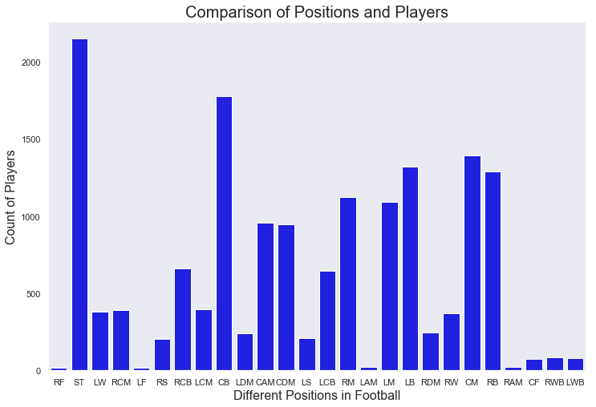

```python
# different positions acquired by the players

plt.figure(figsize = (12, 8))
sns.set(style = 'dark', palette = 'colorblind', color_codes = True)
ax = sns.countplot('Position', data = fifa_df, color = 'blue')
ax.set_xlabel(xlabel = 'Different Positions in Football', fontsize = 16)
ax.set_ylabel(ylabel = 'Count of Players', fontsize = 16)
ax.set_title(label = 'Comparison of Positions and Players', fontsize = 20)
plt.show()
```

Data contains more number of Strikers and center back players.

There is less number of players in the position RWB, LWB, Forward so there might be greater demand and the wages might be higher for players playing in these position

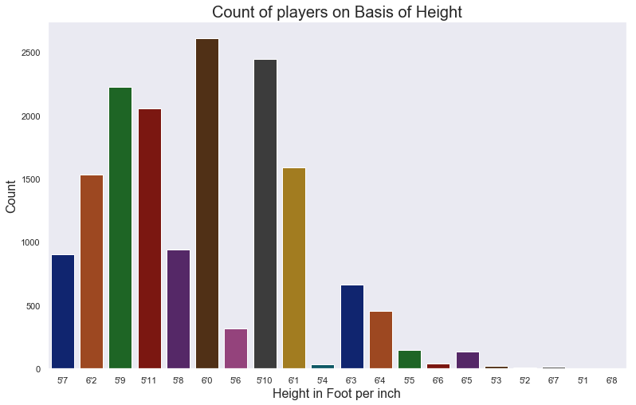

```python
# Height of Players

plt.figure(figsize = (13, 8))
ax = sns.countplot(x = 'Height', data = fifa_df, palette = 'dark')
ax.set_title(label = 'Count of players on Basis of Height', fontsize = 20)
ax.set_xlabel(xlabel = 'Height in Foot per inch', fontsize = 16)
ax.set_ylabel(ylabel = 'Count', fontsize = 16)
plt.show()
```

Football players normally are of height 5'7 to 6'1

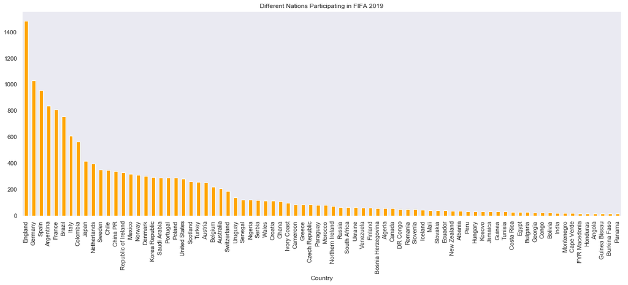

```python
#Different nations participating in the FIFA

fifa_df['Nationality'].value_counts().head(80).plot.bar(color = 'orange', figsize = (20, 7))
plt.title('Different Nations Participating in FIFA 2019')
plt.xlabel('Country')
plt.show()
```

England, Germany, Spain have maximum number of players

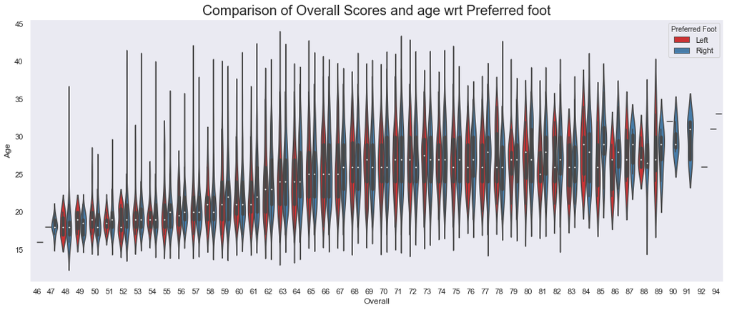

```python
# violin plot

plt.rcParams['figure.figsize'] = (18, 7)
sns.violinplot(fifa_df['Overall'], fifa_df['Age'], hue = fifa_df['Preferred Foot'], palette = 'Set1')
plt.title('Comparison of Overall Scores and age wrt Preferred foot', fontsize = 20)
```

This is very interesting graph which says that the mean of the over all rating of players increase as the age of the player increases. There are certainly outliers for this but normally this graph shows that experience improves the game and there by the rating!!

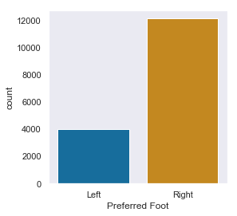

```python
plt.figure(figsize = (4,4))
sns.countplot(x='Preferred Foot', data=fifa_df)
```

In the world, there are more number of players who play with their right foot as strong foot.

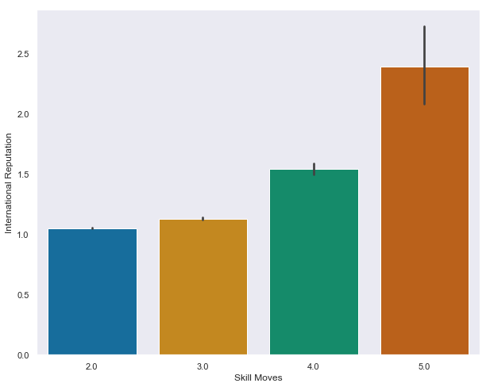

```python
plt.figure(figsize = (10, 8))
sns.barplot(x='Skill Moves',y='International Reputation',data=fifa_df)
```

This confirms the fact that if the skill is high then the reputation would also be high

```python
#Converting money into float

def convert_money(M, to_be_removed = to_be_removed, to_be_multiplied = to_be_multiplied):
    M = str(M).lower()
    for i in to_be_removed:
        M = M.replace(i,'')
    for j in to_be_multiplied.keys():
        if j in M:
            M = float(M.replace(j,''))*to_be_multiplied[j]
            break
    return float(M)

fifa_df.Wage = fifa_df.Wage.apply(lambda x: convert_money(x))
fifa_df.Value = fifa_df.Value.apply(lambda x: convert_money(x))
fifa_df['Release Clause'] = fifa_df['Release Clause'].apply(lambda x: convert_money(x))
```

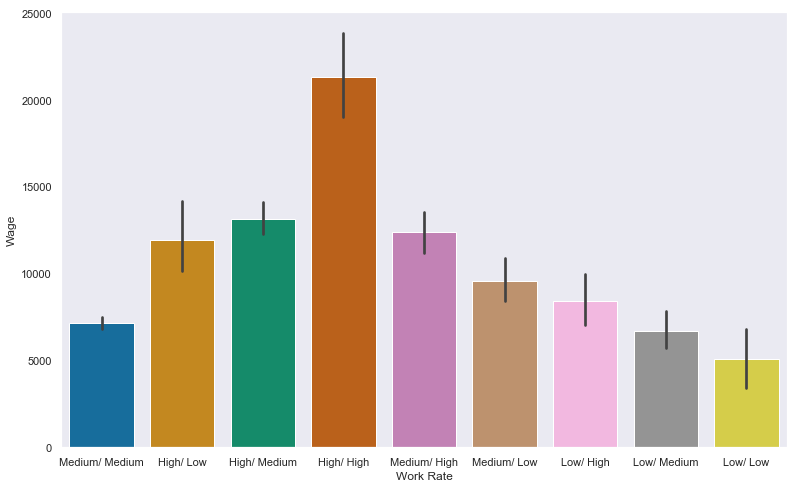

```python
plt.figure(figsize = (13,8))
sns.barplot(x='Work Rate',y=fifa_df.Wage,data=fifa_df)
```

Again this is an interesting graph and throws light on how players are paid.

It also speaks that attackers are paid more than the defenders which confirms our assumtion stated above that the scarcity of forward players might help them earn more

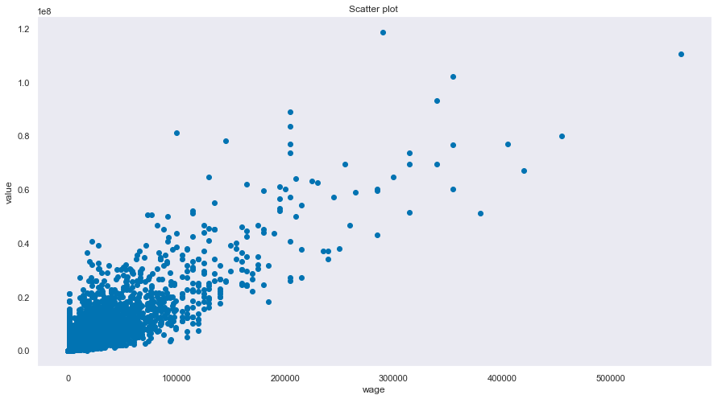

```python
plt.scatter(fifa_df.Wage,fifa_df.Value)
plt.title("Scatter plot ")
plt.xlabel("wage")
plt.ylabel("value")
plt.show()
```

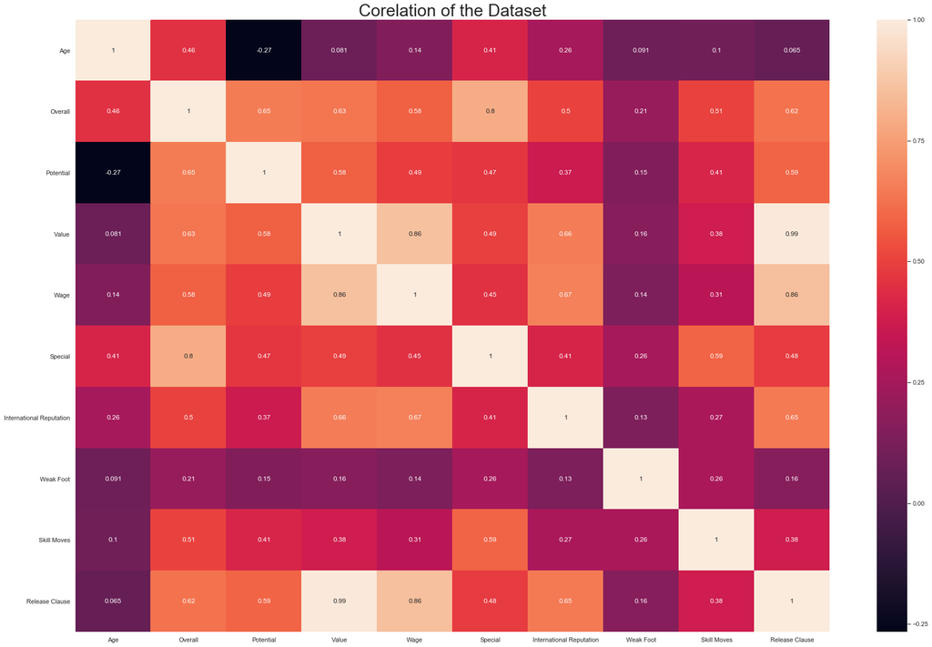

```python
# plotting a correlation heatmap

plt.rcParams['figure.figsize'] = (30, 20)
sns.heatmap(fifa_df[['Age', 'Nationality', 'Overall', 'Potential', 'Club', 'Value',
                    'Wage', 'Special', 'Preferred Foot', 'International Reputation', 'Weak Foot',
                    'Skill Moves', 'Work Rate', 'Body Type', 'Position', 'Height', 'Weight', 'Release Clause']].corr(), annot = True)

plt.title('Corelation of the Dataset', fontsize = 30)
plt.show()
```

I see a very interesting negative corelation between potential and age. Which means many players lose the contidence of the managers/ potential to perform in the next game as they are aged!!

Reputation of the player gets him more money than the overall rating of the player!! Potential of the player also contributes in decides the money which he takes home!

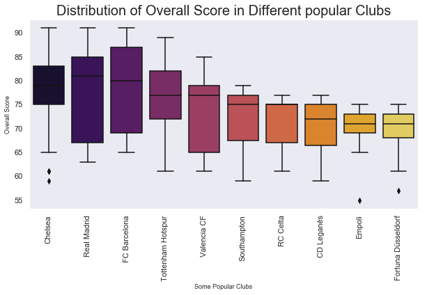

```python
plt.figure(figsize = (10,5))
some_clubs = ('CD Leganés', 'Southampton', 'RC Celta', 'Empoli', 'Fortuna Düsseldorf', 'Manchestar City',
             'Tottenham Hotspur', 'FC Barcelona', 'Valencia CF', 'Chelsea', 'Real Madrid')

data_clubs = fifa_df.loc[fifa_df['Club'].isin(some_clubs) & fifa_df['Overall']]

plt.rcParams['figure.figsize'] = (15, 8)
ax = sns.boxplot(x = data_clubs['Club'], y = data_clubs['Overall'], palette = 'inferno')
ax.set_xlabel(xlabel = 'Some Popular Clubs', fontsize = 9)
ax.set_ylabel(ylabel = 'Overall Score', fontsize = 9)
ax.set_title(label = 'Distribution of Overall Score in Different popular Clubs', fontsize = 20)
plt.xticks(rotation = 90)
plt.show()
```

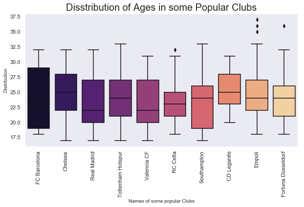

```python
some_clubs = ('CD Leganés', 'Southampton', 'RC Celta', 'Empoli', 'Fortuna Düsseldorf', 'Manchestar City',
             'Tottenham Hotspur', 'FC Barcelona', 'Valencia CF', 'Chelsea', 'Real Madrid')

data_club = fifa_df.loc[fifa_df['Club'].isin(some_clubs) & fifa_df['Wage']]

plt.rcParams['figure.figsize'] = (10, 5)
ax = sns.boxplot(x = 'Club', y = 'Age', data = data_club, palette = 'magma')
ax.set_xlabel(xlabel = 'Names of some popular Clubs', fontsize = 10)
ax.set_ylabel(ylabel = 'Distribution', fontsize = 10)
ax.set_title(label = 'Disstribution of Ages in some Popular Clubs', fontsize = 20)
plt.xticks(rotation = 90)
plt.show()
```

FC Barcelona has players of all age group.

Chelsea has players of mid aged(Football age).

Real Madrid has mostly young and some mid aged players.

# HOW TO APPROACH THE PROBLEM?

1. Decide on the perspective to segment :

   I see there are 3 many aspects for this problem apart from the country and club. They are:

   A) Money B) Skill C) Position

   ```
   Value, Wage and Release Clause comes under Money.

   'Finishing', 'HeadingAccuracy', 'ShortPassing', 'Volleys', 'Dribbling',
   'Curve', 'FKAccuracy', 'LongPassing', 'BallControl', 'Acceleration',
   'SprintSpeed', 'Agility', 'Reactions', 'Balance', 'ShotPower',
   'Jumping', 'Stamina', 'Strength', 'LongShots', 'Aggression',
   'Interceptions', 'Positioning', 'Vision', 'Penalties', 'Composure',
   'Marking', 'StandingTackle', 'SlidingTackle', 'GKDiving', 'GKHandling',
   'GKKicking', 'GKPositioning', 'GKReflexes' comes under Skills.

   'LS', 'ST', 'RS', 'LW', 'LF', 'CF', 'RF', 'RW',
   'LAM', 'CAM', 'RAM', 'LM', 'LCM', 'CM', 'RCM', 'RM', 'LWB', 'LDM',
   'CDM', 'RDM', 'RWB', 'LB', 'LCB', 'CB', 'RCB', 'RB' comes under Position.
   ```

2. Data Cleaning:

   A) This deals with droping the unwanted cloumns such as Name, id, Flag, photo etc. Dropping the coulmns is subjective to each of the analyst. I have tried here to drop the cloumns which are unique and columns which do not belong to Money, skill or position.

   B) Cleaning the data ie., columns with special chars are processed to remove them to get float.

   C) Convert the categorical columns using one hot encoding.

   D) Treating missing values.
3. I would consider clustering as also segmentation where in we would be segmenting the data set based on multiple conditions using multiple columns.
4. Applying different types of clustering.
5. Checking if we have got a meaningful segments of the data set seperated out. If not we might have to look into a different approach.
6. Conclusion

# Data preparation

```python
# Declaring diff types of columns

# Columns dealing with the position rating.
position_col = ['LS', 'ST', 'RS', 'LW', 'LF', 'CF', 'RF', 'RW',
       'LAM', 'CAM', 'RAM', 'LM', 'LCM', 'CM', 'RCM', 'RM', 'LWB', 'LDM',
       'CDM', 'RDM', 'RWB', 'LB', 'LCB', 'CB', 'RCB', 'RB']

# Columns dealing with the skills.
skills_col = ['Crossing',
       'Finishing', 'HeadingAccuracy', 'ShortPassing', 'Volleys', 'Dribbling',
       'Curve', 'FKAccuracy', 'LongPassing', 'BallControl', 'Acceleration',
       'SprintSpeed', 'Agility', 'Reactions', 'Balance', 'ShotPower',
       'Jumping', 'Stamina', 'Strength', 'LongShots', 'Aggression',
       'Interceptions', 'Positioning', 'Vision', 'Penalties', 'Composure',
       'Marking', 'StandingTackle', 'SlidingTackle', 'GKDiving', 'GKHandling',
       'GKKicking', 'GKPositioning', 'GKReflexes']

money_col = ['Value', 'Wage','Release Clause']

# Categorical columns.
cat_col = [ 'attack', 'defence']

# Column which can be used to derive different columns.
derivative_col = ['Work Rate']

# Colunms which can be dropped.
columns_drop = ['Unnamed: 0', 'ID', 'Name',"Photo","Flag",'Club Logo','Jersey Number',
                'Loaned From','Joined','Contract Valid Until','Weight','Nationality',
                'Club','Height','Weight','Position','Preferred Foot', 'Body Type', 'Real Face']
```

```python
#Converting money into float

def convert_money(M, to_be_removed = to_be_removed, to_be_multiplied = to_be_multiplied):
    M = str(M).lower()
    for i in to_be_removed:
        M = M.replace(i,'')
    for j in to_be_multiplied.keys():
        if j in M:
            M = float(M.replace(j,''))*to_be_multiplied[j]
            break
    return float(M)

# Treating missing values.
def imputation(df):
    imp = SimpleImputer(strategy="most_frequent")
    return pd.DataFrame(df, columns=df.columns)

# As the columns such as value or wages are in millions, rating is in the range of 0-10 or 0-100. We see different ranges
#from column to column so I have decided to scale all the columns.
def scaling(df):
    scale = StandardScaler()
    df_scaled = scale.fit_transform(df)

    df_scaled = pd.DataFrame(df_scaled,columns=df.columns)

    return df_scaled, scale

# This is an optional function. This was created initially when I had considered all the columns for the analysis.
def pca_df(df):
    pca = PCA()
    df_pca = pca.fit_transform(df)

    return df_pca, pca

def plot(pca):
    n_components = min(np.where(np.cumsum(pca.explained_variance_ratio_)>0.99)[0]+1)

#     fig = plt.figure()
#     ax = fig.add_axes([0,0,1,1],True)
#     ax2 = ax.twinx()
#     ax.plot(pca.explained_variance_ratio_, label='Variance',)
#     ax2.plot(np.cumsum(pca.explained_variance_ratio_), label='Cumulative Variance',color = 'red');
#     ax.set_title('n_components needed for >100% explained variance: {}'.format(n_components));
#     ax.axvline(n_components, linestyle='dashed', color='black')
#     ax2.axhline(np.cumsum(pca.explained_variance_ratio_)[n_components], linestyle='dashed', color='black')
#     fig.legend(loc=(0.6,0.2));
#     fig.show()
#     plt.savefig("first.ps")
    return n_components

# Using KMeans.
def get_kmeans_score(data, center):

    print(center)

    kmeans = MiniBatchKMeans(n_clusters=center)

    model = kmeans.fit(data)

    score = np.abs(model.score(data))

    return score

def plot_kmeans(df):
    scores = []
    centers = list(range(1,30))
    for center in centers:
        scores.append(get_kmeans_score(df, center))

    plt.plot(centers, scores, linestyle='--', marker='o', color='b');
    plt.xlabel('K');
    plt.ylabel('SSE');
    plt.title('SSE vs. K');
    plt.show();
    plt.close();
```

```python
#Converting the setps used for data preparation in to a function

def data_preparation(position_col, skills_col, cat_col, derivative_col, columns_drop,
                     create_position_df = True, create_skill_df = True, create_money_df = True):

    # Dropping the rows with NAs in the position columns. This is because, there were consistant no of missing values
    # in all the columns so droping those rows.
    fifa_df.dropna(subset=position_col, axis=0, inplace=True)
    fifa_df.reset_index(inplace=True, drop=True)

    # Droping the columns which are decided above
    fifa_df_ = fifa_df.drop(columns_drop, axis=1)


    fifa_df_.Wage = fifa_df_.Wage.apply(lambda x: convert_money(x))
    fifa_df_.Value = fifa_df_.Value.apply(lambda x: convert_money(x))
    fifa_df_['Release Clause'] = fifa_df_['Release Clause'].apply(lambda x: convert_money(x))

    if 'Body Type' in fifa_df_.columns:
        fifa_df_['Body Type'] = fifa_df_['Body Type'].apply(lambda i: replace_body_type[i] if i in list(replace_body_type.keys()) else i)

    # Seperating out position as a seperate df
    position_df = fifa_df_[position_col]
    fifa_df_.drop(position_col, axis = 1, inplace = True)
    # Spliting the column into 2 parts. Assuming the first term as the rating of the player for that particular position,
    # I have considered the first part of each of the columns.
    for col in position_df.columns:
        position_df[col] = position_df[col].apply(lambda i : float(i.split("+")[0]))

#     if not create_position_df:
#         fifa_df_ = pd.concat([fifa_df_,position_df], axis=1)

    # Seperating out skill as a seperate df
    if create_skill_df:
        skill_df = fifa_df_[skills_col]
        fifa_df_.drop(skills_col, axis = 1, inplace = True)

    # Seperating out money as a seperate df
    if create_money_df:
        money_df = fifa_df_[money_col]
        fifa_df_.drop(money_col, axis = 1, inplace = True)


    fifa_df_['Work Rate'] = fifa_df_['Work Rate'].apply(lambda i : i.replace(" ","").split("/") if type(i) == str else ["Low","Low"])
    new_work_rate_col = ['attack','defence']
    fifa_df_[new_work_rate_col] = pd.DataFrame(fifa_df_['Work Rate'].tolist(), index= fifa_df_.index)
    fifa_df_.drop(['Work Rate'], axis = 1, inplace=True)
    cat_col = cat_col

    if "Height" in fifa_df_.columns:
        fifa_df_.Height = fifa_df_.Height.fillna("5'5")
        fifa_df_.Height = fifa_df_.Height.apply(lambda i : float(i.replace("'",".")))

    fifa_df_cat_con = pd.get_dummies(fifa_df_, prefix=cat_col, columns=cat_col, drop_first=True)

    fifa_df_cat_con_imp = imputation(fifa_df_cat_con.copy())

    df_scaled, scale = scaling(fifa_df_cat_con_imp.copy())

    return df_scaled, skill_df, position_df, money_df, scale
```

```python
df_scaled, skill_df, position_df, money_df, scale = data_preparation(position_col, skills_col, cat_col, derivative_col, columns_drop,
                     create_position_df = True, create_skill_df = True)
```

```
1
2
3
4
5
6
7
8
9
10
11
12
13
14
15
16
17
18
19
20
21
22
23
24
25
26
27
28
29
```

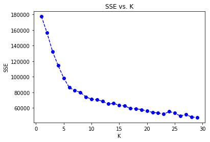

```python
plot_kmeans(df_scaled)
```

```
1
2
3
4
5
6
7
8
9
10
11
12
13
14
15
16
17
18
19
20
21
22
23
24
25
26
27
28
29
```

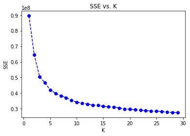

```python
plot_kmeans(skill_df)
```

```
1
2
3
4
5
6
7
8
9
10
11
12
13
14
15
16
17
18
19
20
21
22
23
24
25
26
27
28
29
```

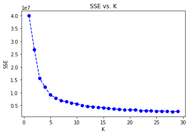

```python
plot_kmeans(position_df)
```

```python
money_df = money_df.fillna(money_df.mean())
```

```python
money_df.isna().sum()
```

```
Value             0
Wage              0
Release Clause    0
dtype: int64
```

```
1
2
3
4
5
6
7
8
9
10
11
12
13
14
15
16
17
18
19
20
21
22
23
24
25
26
27
28
29
```

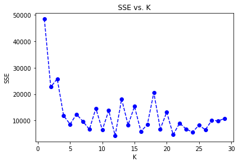

```python
money_df_imp_scale,_ = scaling(money_df)
plot_kmeans(money_df_imp_scale)
```

Looing at the graph, clustering over money related columns might not be a good idea

# Clustering

```python
kmeans_k = KMeans(5)
model_k = kmeans_k.fit(df_scaled)
prediction = model_k.predict(df_scaled)
```

```python
df_scaled_inv = pd.DataFrame(scale.inverse_transform(df_scaled), columns=df_scaled.columns)
df_scaled_inv["Group"] = prediction
```

```python
df_scaled_inv.shape
```

```
(16122, 12)
```

```python
df_scaled_inv.Group.value_counts()
```

```
1    6588
3    5887
0    1444
4    1289
2     914
Name: Group, dtype: int64
```

```python
df_scaled.columns
```

```
Index(['Age', 'Overall', 'Potential', 'Special', 'International Reputation',
       'Weak Foot', 'Skill Moves', 'attack_Low', 'attack_Medium',
       'defence_Low', 'defence_Medium'],
      dtype='object')
```

```python
df_scaled_inv[df_scaled_inv["Group"] == 1]
```

|  | Age | Overall | Potential | Special | International Reputation | Weak Foot | Skill Moves | attack_Low | attack_Medium | defence_Low | defence_Medium | Group |
| --- | --- | --- | --- | --- | --- | --- | --- | --- | --- | --- | --- | --- |
| 868 | 28.0 | 77.0 | 77.0 | 1500.0 | 1.0 | 2.0 | 2.0 | 0.0 | 1.0 | 0.0 | 1.0 | 1 |
| 1367 | 27.0 | 76.0 | 78.0 | 1478.0 | 1.0 | 2.0 | 2.0 | 0.0 | 1.0 | 0.0 | 1.0 | 1 |
| 1488 | 26.0 | 75.0 | 79.0 | 1431.0 | 1.0 | 3.0 | 2.0 | 0.0 | 1.0 | 0.0 | 1.0 | 1 |
| 1775 | 25.0 | 75.0 | 77.0 | 1557.0 | 1.0 | 1.0 | 2.0 | 0.0 | 1.0 | 0.0 | 0.0 | 1 |
| 1938 | 24.0 | 74.0 | 76.0 | 1481.0 | 1.0 | 3.0 | 2.0 | 0.0 | 1.0 | 0.0 | 0.0 | 1 |
| 1986 | 26.0 | 74.0 | 74.0 | 1641.0 | 1.0 | 2.0 | 2.0 | 0.0 | 1.0 | 0.0 | 1.0 | 1 |
| 2127 | 22.0 | 74.0 | 81.0 | 1538.0 | 1.0 | 2.0 | 2.0 | 0.0 | 1.0 | 0.0 | 0.0 | 1 |
| 2169 | 27.0 | 74.0 | 76.0 | 1483.0 | 1.0 | 2.0 | 2.0 | 0.0 | 1.0 | 0.0 | 0.0 | 1 |
| 2189 | 23.0 | 74.0 | 81.0 | 1464.0 | 1.0 | 3.0 | 2.0 | 0.0 | 1.0 | 0.0 | 1.0 | 1 |
| 2214 | 31.0 | 74.0 | 74.0 | 1439.0 | 2.0 | 2.0 | 2.0 | 0.0 | 1.0 | 0.0 | 1.0 | 1 |
| 2232 | 23.0 | 74.0 | 78.0 | 1651.0 | 1.0 | 2.0 | 2.0 | 0.0 | 1.0 | 0.0 | 1.0 | 1 |
| 2324 | 30.0 | 74.0 | 74.0 | 1485.0 | 1.0 | 2.0 | 2.0 | 0.0 | 1.0 | 0.0 | 0.0 | 1 |
| 2340 | 29.0 | 74.0 | 74.0 | 1468.0 | 1.0 | 2.0 | 2.0 | 0.0 | 1.0 | 0.0 | 0.0 | 1 |
| 2406 | 32.0 | 73.0 | 73.0 | 1508.0 | 2.0 | 2.0 | 2.0 | 0.0 | 1.0 | 0.0 | 1.0 | 1 |
| 2458 | 27.0 | 73.0 | 75.0 | 1501.0 | 1.0 | 3.0 | 2.0 | 0.0 | 1.0 | 0.0 | 0.0 | 1 |
| 2520 | 24.0 | 73.0 | 80.0 | 1590.0 | 1.0 | 2.0 | 2.0 | 0.0 | 1.0 | 0.0 | 1.0 | 1 |
| 2574 | 23.0 | 73.0 | 77.0 | 1616.0 | 1.0 | 2.0 | 2.0 | 0.0 | 1.0 | 0.0 | 0.0 | 1 |
| 2593 | 25.0 | 73.0 | 76.0 | 1540.0 | 1.0 | 3.0 | 2.0 | 0.0 | 1.0 | 0.0 | 1.0 | 1 |
| 2617 | 27.0 | 73.0 | 74.0 | 1502.0 | 1.0 | 2.0 | 2.0 | 0.0 | 1.0 | 0.0 | 1.0 | 1 |
| 2622 | 27.0 | 73.0 | 74.0 | 1517.0 | 1.0 | 2.0 | 2.0 | 0.0 | 1.0 | 0.0 | 0.0 | 1 |
| 2743 | 28.0 | 73.0 | 74.0 | 1533.0 | 1.0 | 3.0 | 2.0 | 0.0 | 1.0 | 0.0 | 1.0 | 1 |
| 2755 | 26.0 | 73.0 | 75.0 | 1519.0 | 1.0 | 3.0 | 2.0 | 0.0 | 1.0 | 0.0 | 1.0 | 1 |
| 2766 | 28.0 | 73.0 | 74.0 | 1580.0 | 1.0 | 2.0 | 2.0 | 0.0 | 1.0 | 0.0 | 1.0 | 1 |
| 2815 | 30.0 | 73.0 | 73.0 | 1669.0 | 1.0 | 2.0 | 2.0 | 0.0 | 1.0 | 0.0 | 1.0 | 1 |
| 2819 | 26.0 | 73.0 | 74.0 | 1593.0 | 1.0 | 3.0 | 2.0 | 0.0 | 1.0 | 0.0 | 1.0 | 1 |
| 2890 | 26.0 | 73.0 | 73.0 | 1696.0 | 1.0 | 2.0 | 2.0 | 0.0 | 1.0 | 0.0 | 1.0 | 1 |
| 2903 | 26.0 | 73.0 | 73.0 | 1527.0 | 1.0 | 3.0 | 2.0 | 0.0 | 1.0 | 0.0 | 1.0 | 1 |
| 2915 | 23.0 | 72.0 | 77.0 | 1601.0 | 1.0 | 3.0 | 2.0 | 0.0 | 1.0 | 0.0 | 1.0 | 1 |
| 2942 | 25.0 | 72.0 | 75.0 | 1537.0 | 1.0 | 3.0 | 2.0 | 0.0 | 1.0 | 0.0 | 1.0 | 1 |
| 2973 | 26.0 | 72.0 | 77.0 | 1343.0 | 1.0 | 2.0 | 2.0 | 0.0 | 1.0 | 0.0 | 1.0 | 1 |
| ... | ... | ... | ... | ... | ... | ... | ... | ... | ... | ... | ... | ... |
| 16088 | 21.0 | 48.0 | 58.0 | 1364.0 | 1.0 | 3.0 | 2.0 | 0.0 | 1.0 | 0.0 | 1.0 | 1 |
| 16089 | 19.0 | 48.0 | 59.0 | 1152.0 | 1.0 | 3.0 | 2.0 | 0.0 | 1.0 | 0.0 | 1.0 | 1 |
| 16090 | 17.0 | 48.0 | 65.0 | 1350.0 | 1.0 | 2.0 | 2.0 | 0.0 | 1.0 | 0.0 | 1.0 | 1 |
| 16093 | 20.0 | 48.0 | 63.0 | 1374.0 | 1.0 | 3.0 | 2.0 | 0.0 | 1.0 | 0.0 | 1.0 | 1 |
| 16094 | 18.0 | 48.0 | 63.0 | 1370.0 | 1.0 | 3.0 | 3.0 | 0.0 | 1.0 | 0.0 | 1.0 | 1 |
| 16095 | 19.0 | 48.0 | 59.0 | 1225.0 | 1.0 | 2.0 | 2.0 | 0.0 | 1.0 | 0.0 | 1.0 | 1 |
| 16096 | 17.0 | 48.0 | 57.0 | 1218.0 | 1.0 | 2.0 | 2.0 | 0.0 | 0.0 | 0.0 | 1.0 | 1 |
| 16097 | 18.0 | 48.0 | 69.0 | 1178.0 | 1.0 | 3.0 | 2.0 | 0.0 | 1.0 | 0.0 | 1.0 | 1 |
| 16098 | 17.0 | 48.0 | 64.0 | 1166.0 | 1.0 | 3.0 | 2.0 | 0.0 | 1.0 | 0.0 | 1.0 | 1 |
| 16099 | 17.0 | 48.0 | 66.0 | 1296.0 | 1.0 | 2.0 | 2.0 | 0.0 | 1.0 | 0.0 | 1.0 | 1 |
| 16101 | 18.0 | 48.0 | 55.0 | 1368.0 | 1.0 | 3.0 | 2.0 | 0.0 | 1.0 | 0.0 | 1.0 | 1 |
| 16102 | 19.0 | 48.0 | 59.0 | 1315.0 | 1.0 | 3.0 | 2.0 | 0.0 | 1.0 | 0.0 | 1.0 | 1 |
| 16103 | 20.0 | 47.0 | 64.0 | 1389.0 | 1.0 | 3.0 | 2.0 | 0.0 | 1.0 | 0.0 | 1.0 | 1 |
| 16104 | 19.0 | 47.0 | 59.0 | 1366.0 | 1.0 | 3.0 | 2.0 | 0.0 | 0.0 | 0.0 | 1.0 | 1 |
| 16105 | 17.0 | 47.0 | 62.0 | 1297.0 | 1.0 | 3.0 | 2.0 | 0.0 | 1.0 | 0.0 | 1.0 | 1 |
| 16106 | 18.0 | 47.0 | 61.0 | 1290.0 | 1.0 | 3.0 | 2.0 | 0.0 | 1.0 | 0.0 | 1.0 | 1 |
| 16107 | 18.0 | 47.0 | 67.0 | 1285.0 | 1.0 | 3.0 | 2.0 | 0.0 | 1.0 | 0.0 | 1.0 | 1 |
| 16108 | 18.0 | 47.0 | 65.0 | 1250.0 | 1.0 | 3.0 | 2.0 | 0.0 | 1.0 | 0.0 | 0.0 | 1 |
| 16110 | 18.0 | 47.0 | 64.0 | 1191.0 | 1.0 | 2.0 | 2.0 | 0.0 | 1.0 | 0.0 | 1.0 | 1 |
| 16111 | 18.0 | 47.0 | 67.0 | 1325.0 | 1.0 | 3.0 | 2.0 | 0.0 | 1.0 | 0.0 | 1.0 | 1 |
| 16112 | 19.0 | 47.0 | 61.0 | 1333.0 | 1.0 | 3.0 | 2.0 | 0.0 | 1.0 | 0.0 | 1.0 | 1 |
| 16113 | 18.0 | 47.0 | 61.0 | 1362.0 | 1.0 | 3.0 | 2.0 | 0.0 | 1.0 | 0.0 | 1.0 | 1 |
| 16114 | 18.0 | 47.0 | 69.0 | 1303.0 | 1.0 | 3.0 | 2.0 | 0.0 | 1.0 | 0.0 | 0.0 | 1 |
| 16115 | 18.0 | 47.0 | 62.0 | 1203.0 | 1.0 | 2.0 | 2.0 | 0.0 | 1.0 | 0.0 | 1.0 | 1 |
| 16116 | 18.0 | 47.0 | 68.0 | 1098.0 | 1.0 | 3.0 | 2.0 | 0.0 | 1.0 | 0.0 | 1.0 | 1 |
| 16117 | 19.0 | 47.0 | 65.0 | 1307.0 | 1.0 | 2.0 | 2.0 | 0.0 | 1.0 | 0.0 | 1.0 | 1 |
| 16118 | 19.0 | 47.0 | 63.0 | 1098.0 | 1.0 | 2.0 | 2.0 | 0.0 | 1.0 | 0.0 | 1.0 | 1 |
| 16119 | 16.0 | 47.0 | 67.0 | 1189.0 | 1.0 | 3.0 | 2.0 | 0.0 | 1.0 | 0.0 | 1.0 | 1 |
| 16120 | 17.0 | 47.0 | 66.0 | 1228.0 | 1.0 | 3.0 | 2.0 | 0.0 | 1.0 | 0.0 | 1.0 | 1 |
| 16121 | 16.0 | 46.0 | 66.0 | 1321.0 | 1.0 | 3.0 | 2.0 | 0.0 | 1.0 | 0.0 | 1.0 | 1 |

6588 rows × 12 columns

```python
df_scaled_inv[df_scaled_inv["Group"] == 2]
```

|  | Age | Overall | Potential | Special | International Reputation | Weak Foot | Skill Moves | attack_Low | attack_Medium | defence_Low | defence_Medium | Group |
| --- | --- | --- | --- | --- | --- | --- | --- | --- | --- | --- | --- | --- |
| 209 | 23.0 | 82.0 | 86.0 | 1705.0 | 2.0 | 3.0 | 2.0 | 1.0 | 0.0 | 0.0 | 1.0 | 2 |
| 228 | 27.0 | 82.0 | 83.0 | 1959.0 | 2.0 | 2.0 | 2.0 | 1.0 | 0.0 | 0.0 | 0.0 | 2 |
| 260 | 29.0 | 82.0 | 82.0 | 1945.0 | 2.0 | 3.0 | 2.0 | 1.0 | 0.0 | 0.0 | 0.0 | 2 |
| 292 | 22.0 | 81.0 | 88.0 | 1717.0 | 2.0 | 3.0 | 2.0 | 1.0 | 0.0 | 0.0 | 1.0 | 2 |
| 304 | 25.0 | 81.0 | 84.0 | 1821.0 | 2.0 | 2.0 | 2.0 | 1.0 | 0.0 | 0.0 | 0.0 | 2 |
| 363 | 21.0 | 80.0 | 85.0 | 1806.0 | 1.0 | 3.0 | 3.0 | 1.0 | 0.0 | 0.0 | 1.0 | 2 |
| 455 | 31.0 | 80.0 | 80.0 | 1792.0 | 2.0 | 2.0 | 2.0 | 1.0 | 0.0 | 0.0 | 1.0 | 2 |
| 574 | 27.0 | 79.0 | 79.0 | 1923.0 | 2.0 | 4.0 | 2.0 | 1.0 | 0.0 | 0.0 | 0.0 | 2 |
| 619 | 28.0 | 79.0 | 79.0 | 1991.0 | 2.0 | 3.0 | 3.0 | 1.0 | 0.0 | 0.0 | 0.0 | 2 |
| 666 | 21.0 | 78.0 | 86.0 | 1738.0 | 1.0 | 3.0 | 2.0 | 1.0 | 0.0 | 0.0 | 0.0 | 2 |
| 712 | 25.0 | 78.0 | 80.0 | 1994.0 | 1.0 | 4.0 | 3.0 | 1.0 | 0.0 | 0.0 | 1.0 | 2 |
| 758 | 26.0 | 78.0 | 80.0 | 1719.0 | 2.0 | 3.0 | 2.0 | 1.0 | 0.0 | 0.0 | 0.0 | 2 |
| 783 | 26.0 | 78.0 | 80.0 | 2050.0 | 2.0 | 3.0 | 3.0 | 1.0 | 0.0 | 0.0 | 1.0 | 2 |
| 805 | 30.0 | 77.0 | 77.0 | 1824.0 | 1.0 | 3.0 | 2.0 | 1.0 | 0.0 | 0.0 | 0.0 | 2 |
| 831 | 23.0 | 77.0 | 83.0 | 1670.0 | 1.0 | 2.0 | 2.0 | 1.0 | 0.0 | 0.0 | 1.0 | 2 |
| 843 | 27.0 | 77.0 | 77.0 | 1742.0 | 2.0 | 2.0 | 2.0 | 1.0 | 0.0 | 0.0 | 0.0 | 2 |
| 864 | 30.0 | 77.0 | 77.0 | 2023.0 | 1.0 | 3.0 | 3.0 | 1.0 | 0.0 | 0.0 | 0.0 | 2 |
| 893 | 28.0 | 77.0 | 79.0 | 1646.0 | 2.0 | 3.0 | 2.0 | 1.0 | 0.0 | 0.0 | 0.0 | 2 |
| 943 | 34.0 | 77.0 | 77.0 | 1796.0 | 1.0 | 3.0 | 2.0 | 1.0 | 0.0 | 0.0 | 1.0 | 2 |
| 957 | 32.0 | 77.0 | 77.0 | 1554.0 | 3.0 | 3.0 | 2.0 | 1.0 | 0.0 | 0.0 | 0.0 | 2 |
| 965 | 29.0 | 77.0 | 77.0 | 1693.0 | 2.0 | 3.0 | 2.0 | 1.0 | 0.0 | 0.0 | 0.0 | 2 |
| 967 | 34.0 | 77.0 | 77.0 | 1728.0 | 2.0 | 3.0 | 2.0 | 1.0 | 0.0 | 0.0 | 0.0 | 2 |
| 998 | 34.0 | 77.0 | 77.0 | 1592.0 | 2.0 | 3.0 | 2.0 | 1.0 | 0.0 | 0.0 | 1.0 | 2 |
| 1019 | 27.0 | 77.0 | 79.0 | 1706.0 | 1.0 | 3.0 | 2.0 | 1.0 | 0.0 | 0.0 | 0.0 | 2 |
| 1024 | 27.0 | 77.0 | 78.0 | 1561.0 | 1.0 | 3.0 | 2.0 | 1.0 | 0.0 | 0.0 | 0.0 | 2 |
| 1039 | 29.0 | 77.0 | 77.0 | 1937.0 | 2.0 | 3.0 | 3.0 | 1.0 | 0.0 | 0.0 | 0.0 | 2 |
| 1094 | 24.0 | 76.0 | 79.0 | 1719.0 | 1.0 | 3.0 | 3.0 | 1.0 | 0.0 | 0.0 | 0.0 | 2 |
| 1149 | 31.0 | 76.0 | 76.0 | 1789.0 | 1.0 | 3.0 | 2.0 | 1.0 | 0.0 | 0.0 | 0.0 | 2 |
| 1155 | 26.0 | 76.0 | 80.0 | 1704.0 | 2.0 | 3.0 | 2.0 | 1.0 | 0.0 | 0.0 | 0.0 | 2 |
| 1172 | 23.0 | 76.0 | 80.0 | 1954.0 | 1.0 | 3.0 | 3.0 | 1.0 | 0.0 | 0.0 | 1.0 | 2 |
| ... | ... | ... | ... | ... | ... | ... | ... | ... | ... | ... | ... | ... |
| 15446 | 22.0 | 54.0 | 60.0 | 1233.0 | 1.0 | 3.0 | 2.0 | 1.0 | 0.0 | 0.0 | 1.0 | 2 |
| 15449 | 19.0 | 54.0 | 66.0 | 1453.0 | 1.0 | 2.0 | 2.0 | 1.0 | 0.0 | 0.0 | 0.0 | 2 |
| 15517 | 21.0 | 54.0 | 63.0 | 1311.0 | 1.0 | 2.0 | 2.0 | 1.0 | 0.0 | 0.0 | 0.0 | 2 |
| 15519 | 21.0 | 54.0 | 64.0 | 1417.0 | 1.0 | 2.0 | 2.0 | 1.0 | 0.0 | 0.0 | 0.0 | 2 |
| 15530 | 19.0 | 54.0 | 69.0 | 1156.0 | 1.0 | 2.0 | 2.0 | 1.0 | 0.0 | 0.0 | 1.0 | 2 |
| 15574 | 19.0 | 54.0 | 71.0 | 1229.0 | 1.0 | 3.0 | 2.0 | 1.0 | 0.0 | 0.0 | 1.0 | 2 |
| 15594 | 20.0 | 54.0 | 66.0 | 1219.0 | 1.0 | 3.0 | 2.0 | 1.0 | 0.0 | 0.0 | 1.0 | 2 |
| 15607 | 20.0 | 53.0 | 63.0 | 1372.0 | 1.0 | 2.0 | 2.0 | 1.0 | 0.0 | 0.0 | 1.0 | 2 |
| 15615 | 24.0 | 53.0 | 58.0 | 1351.0 | 1.0 | 2.0 | 2.0 | 1.0 | 0.0 | 0.0 | 1.0 | 2 |
| 15621 | 17.0 | 53.0 | 74.0 | 1222.0 | 1.0 | 1.0 | 2.0 | 1.0 | 0.0 | 0.0 | 1.0 | 2 |
| 15635 | 18.0 | 53.0 | 72.0 | 1473.0 | 1.0 | 2.0 | 2.0 | 1.0 | 0.0 | 0.0 | 1.0 | 2 |
| 15657 | 18.0 | 53.0 | 67.0 | 1256.0 | 1.0 | 2.0 | 2.0 | 1.0 | 0.0 | 0.0 | 1.0 | 2 |
| 15659 | 20.0 | 53.0 | 62.0 | 1245.0 | 1.0 | 3.0 | 2.0 | 1.0 | 0.0 | 0.0 | 1.0 | 2 |
| 15730 | 20.0 | 53.0 | 61.0 | 1357.0 | 1.0 | 2.0 | 2.0 | 1.0 | 0.0 | 0.0 | 1.0 | 2 |
| 15773 | 20.0 | 52.0 | 59.0 | 1166.0 | 1.0 | 2.0 | 2.0 | 1.0 | 0.0 | 0.0 | 1.0 | 2 |
| 15820 | 21.0 | 52.0 | 60.0 | 1248.0 | 1.0 | 3.0 | 2.0 | 1.0 | 0.0 | 0.0 | 1.0 | 2 |
| 15839 | 18.0 | 52.0 | 65.0 | 1301.0 | 1.0 | 2.0 | 2.0 | 1.0 | 0.0 | 0.0 | 1.0 | 2 |
| 15843 | 21.0 | 52.0 | 56.0 | 1489.0 | 1.0 | 3.0 | 2.0 | 1.0 | 0.0 | 0.0 | 0.0 | 2 |
| 15871 | 20.0 | 51.0 | 65.0 | 1383.0 | 1.0 | 2.0 | 2.0 | 1.0 | 0.0 | 0.0 | 0.0 | 2 |
| 15902 | 17.0 | 51.0 | 74.0 | 1203.0 | 1.0 | 3.0 | 2.0 | 1.0 | 0.0 | 0.0 | 0.0 | 2 |
| 15927 | 23.0 | 51.0 | 57.0 | 1209.0 | 1.0 | 3.0 | 2.0 | 1.0 | 0.0 | 0.0 | 0.0 | 2 |
| 15953 | 22.0 | 51.0 | 59.0 | 1245.0 | 1.0 | 2.0 | 2.0 | 1.0 | 0.0 | 0.0 | 1.0 | 2 |
| 15981 | 17.0 | 50.0 | 72.0 | 1410.0 | 1.0 | 3.0 | 2.0 | 1.0 | 0.0 | 1.0 | 0.0 | 2 |
| 16005 | 17.0 | 50.0 | 70.0 | 1122.0 | 1.0 | 2.0 | 2.0 | 1.0 | 0.0 | 0.0 | 1.0 | 2 |
| 16011 | 18.0 | 50.0 | 65.0 | 1160.0 | 1.0 | 3.0 | 2.0 | 1.0 | 0.0 | 0.0 | 1.0 | 2 |
| 16027 | 17.0 | 50.0 | 66.0 | 1154.0 | 1.0 | 2.0 | 2.0 | 1.0 | 0.0 | 0.0 | 0.0 | 2 |
| 16033 | 18.0 | 50.0 | 67.0 | 1372.0 | 1.0 | 2.0 | 2.0 | 1.0 | 0.0 | 0.0 | 0.0 | 2 |
| 16075 | 19.0 | 49.0 | 62.0 | 1320.0 | 1.0 | 3.0 | 2.0 | 1.0 | 0.0 | 1.0 | 0.0 | 2 |
| 16100 | 18.0 | 48.0 | 65.0 | 1311.0 | 1.0 | 3.0 | 2.0 | 1.0 | 0.0 | 0.0 | 1.0 | 2 |
| 16109 | 18.0 | 47.0 | 64.0 | 1325.0 | 1.0 | 3.0 | 2.0 | 1.0 | 0.0 | 0.0 | 1.0 | 2 |

914 rows × 12 columns

```python
df_scaled_inv[df_scaled_inv["Group"] == 3]
```

|  | Age | Overall | Potential | Special | International Reputation | Weak Foot | Skill Moves | attack_Low | attack_Medium | defence_Low | defence_Medium | Group |
| --- | --- | --- | --- | --- | --- | --- | --- | --- | --- | --- | --- | --- |
| 67 | 23.0 | 85.0 | 92.0 | 1800.0 | 1.0 | 4.0 | 2.0 | 0.0 | 1.0 | 0.0 | 0.0 | 3 |
| 138 | 26.0 | 83.0 | 83.0 | 2095.0 | 1.0 | 4.0 | 4.0 | 0.0 | 0.0 | 0.0 | 1.0 | 3 |
| 139 | 26.0 | 83.0 | 83.0 | 1894.0 | 1.0 | 3.0 | 2.0 | 0.0 | 1.0 | 0.0 | 1.0 | 3 |
| 155 | 26.0 | 83.0 | 85.0 | 1967.0 | 1.0 | 4.0 | 4.0 | 0.0 | 0.0 | 0.0 | 1.0 | 3 |
| 194 | 22.0 | 82.0 | 87.0 | 2055.0 | 1.0 | 3.0 | 4.0 | 0.0 | 1.0 | 0.0 | 0.0 | 3 |
| 195 | 21.0 | 82.0 | 90.0 | 2120.0 | 1.0 | 3.0 | 4.0 | 0.0 | 1.0 | 0.0 | 1.0 | 3 |
| 196 | 30.0 | 82.0 | 82.0 | 2061.0 | 1.0 | 4.0 | 2.0 | 0.0 | 0.0 | 0.0 | 1.0 | 3 |
| 197 | 34.0 | 82.0 | 82.0 | 2003.0 | 1.0 | 3.0 | 2.0 | 0.0 | 0.0 | 0.0 | 1.0 | 3 |
| 202 | 22.0 | 82.0 | 88.0 | 1953.0 | 1.0 | 3.0 | 3.0 | 0.0 | 1.0 | 0.0 | 0.0 | 3 |
| 203 | 23.0 | 82.0 | 88.0 | 1775.0 | 1.0 | 4.0 | 2.0 | 0.0 | 1.0 | 0.0 | 0.0 | 3 |
| 205 | 24.0 | 82.0 | 87.0 | 2023.0 | 1.0 | 2.0 | 3.0 | 0.0 | 0.0 | 0.0 | 0.0 | 3 |
| 213 | 25.0 | 82.0 | 88.0 | 2068.0 | 1.0 | 3.0 | 3.0 | 0.0 | 0.0 | 0.0 | 0.0 | 3 |
| 214 | 25.0 | 82.0 | 84.0 | 2180.0 | 1.0 | 4.0 | 4.0 | 0.0 | 0.0 | 0.0 | 0.0 | 3 |
| 223 | 25.0 | 82.0 | 85.0 | 1853.0 | 1.0 | 3.0 | 2.0 | 0.0 | 0.0 | 0.0 | 0.0 | 3 |
| 276 | 30.0 | 81.0 | 81.0 | 1853.0 | 1.0 | 5.0 | 4.0 | 0.0 | 1.0 | 0.0 | 1.0 | 3 |
| 277 | 20.0 | 81.0 | 89.0 | 2011.0 | 1.0 | 4.0 | 4.0 | 0.0 | 0.0 | 0.0 | 1.0 | 3 |
| 279 | 21.0 | 81.0 | 89.0 | 2064.0 | 1.0 | 3.0 | 4.0 | 0.0 | 1.0 | 0.0 | 1.0 | 3 |
| 281 | 22.0 | 81.0 | 86.0 | 2071.0 | 1.0 | 3.0 | 4.0 | 0.0 | 0.0 | 0.0 | 0.0 | 3 |
| 282 | 22.0 | 81.0 | 89.0 | 2094.0 | 1.0 | 4.0 | 4.0 | 0.0 | 1.0 | 0.0 | 1.0 | 3 |
| 284 | 21.0 | 81.0 | 88.0 | 2059.0 | 1.0 | 3.0 | 4.0 | 0.0 | 1.0 | 0.0 | 1.0 | 3 |
| 286 | 30.0 | 81.0 | 81.0 | 2084.0 | 1.0 | 4.0 | 4.0 | 0.0 | 0.0 | 0.0 | 1.0 | 3 |
| 300 | 25.0 | 81.0 | 84.0 | 1917.0 | 1.0 | 4.0 | 3.0 | 0.0 | 0.0 | 0.0 | 1.0 | 3 |
| 334 | 28.0 | 81.0 | 81.0 | 1971.0 | 1.0 | 4.0 | 4.0 | 0.0 | 0.0 | 0.0 | 1.0 | 3 |
| 364 | 19.0 | 80.0 | 89.0 | 1876.0 | 1.0 | 5.0 | 4.0 | 0.0 | 1.0 | 0.0 | 1.0 | 3 |
| 365 | 21.0 | 80.0 | 89.0 | 2096.0 | 1.0 | 3.0 | 4.0 | 0.0 | 0.0 | 0.0 | 0.0 | 3 |
| 366 | 20.0 | 80.0 | 90.0 | 2048.0 | 1.0 | 4.0 | 4.0 | 0.0 | 0.0 | 0.0 | 1.0 | 3 |
| 367 | 21.0 | 80.0 | 87.0 | 2062.0 | 1.0 | 4.0 | 4.0 | 0.0 | 1.0 | 0.0 | 1.0 | 3 |
| 368 | 22.0 | 80.0 | 88.0 | 1991.0 | 1.0 | 3.0 | 3.0 | 0.0 | 0.0 | 0.0 | 1.0 | 3 |
| 369 | 24.0 | 80.0 | 84.0 | 1988.0 | 1.0 | 2.0 | 4.0 | 0.0 | 0.0 | 0.0 | 0.0 | 3 |
| 370 | 30.0 | 80.0 | 80.0 | 2068.0 | 1.0 | 4.0 | 4.0 | 0.0 | 1.0 | 0.0 | 1.0 | 3 |
| ... | ... | ... | ... | ... | ... | ... | ... | ... | ... | ... | ... | ... |
| 12785 | 23.0 | 61.0 | 65.0 | 1722.0 | 1.0 | 3.0 | 3.0 | 0.0 | 0.0 | 0.0 | 1.0 | 3 |
| 12792 | 18.0 | 61.0 | 79.0 | 1652.0 | 1.0 | 3.0 | 3.0 | 0.0 | 0.0 | 0.0 | 0.0 | 3 |
| 12804 | 32.0 | 61.0 | 61.0 | 1712.0 | 1.0 | 5.0 | 3.0 | 0.0 | 0.0 | 0.0 | 1.0 | 3 |
| 12810 | 21.0 | 61.0 | 71.0 | 1590.0 | 1.0 | 3.0 | 3.0 | 0.0 | 0.0 | 0.0 | 1.0 | 3 |
| 12813 | 22.0 | 61.0 | 71.0 | 1677.0 | 1.0 | 4.0 | 3.0 | 0.0 | 1.0 | 0.0 | 1.0 | 3 |
| 12836 | 20.0 | 61.0 | 71.0 | 1480.0 | 1.0 | 3.0 | 4.0 | 0.0 | 1.0 | 0.0 | 1.0 | 3 |
| 12878 | 26.0 | 61.0 | 62.0 | 1612.0 | 1.0 | 4.0 | 3.0 | 0.0 | 0.0 | 0.0 | 1.0 | 3 |
| 12901 | 17.0 | 61.0 | 81.0 | 1526.0 | 1.0 | 5.0 | 3.0 | 0.0 | 0.0 | 0.0 | 1.0 | 3 |
| 12915 | 27.0 | 61.0 | 62.0 | 1681.0 | 1.0 | 3.0 | 3.0 | 0.0 | 0.0 | 0.0 | 1.0 | 3 |
| 12931 | 33.0 | 61.0 | 61.0 | 1728.0 | 1.0 | 4.0 | 3.0 | 0.0 | 1.0 | 0.0 | 1.0 | 3 |
| 12999 | 22.0 | 61.0 | 68.0 | 1536.0 | 1.0 | 3.0 | 4.0 | 0.0 | 1.0 | 0.0 | 1.0 | 3 |
| 13098 | 19.0 | 61.0 | 72.0 | 1542.0 | 1.0 | 3.0 | 4.0 | 0.0 | 1.0 | 0.0 | 1.0 | 3 |
| 13131 | 21.0 | 61.0 | 73.0 | 1572.0 | 1.0 | 3.0 | 3.0 | 0.0 | 0.0 | 0.0 | 1.0 | 3 |
| 13154 | 17.0 | 61.0 | 84.0 | 1613.0 | 1.0 | 3.0 | 3.0 | 0.0 | 1.0 | 0.0 | 1.0 | 3 |
| 13193 | 18.0 | 61.0 | 79.0 | 1490.0 | 1.0 | 3.0 | 3.0 | 0.0 | 0.0 | 0.0 | 1.0 | 3 |
| 13303 | 19.0 | 60.0 | 76.0 | 1529.0 | 1.0 | 3.0 | 3.0 | 0.0 | 0.0 | 0.0 | 1.0 | 3 |
| 13379 | 22.0 | 60.0 | 68.0 | 1532.0 | 1.0 | 4.0 | 3.0 | 0.0 | 0.0 | 0.0 | 1.0 | 3 |
| 13407 | 28.0 | 60.0 | 60.0 | 1560.0 | 1.0 | 4.0 | 3.0 | 0.0 | 0.0 | 0.0 | 0.0 | 3 |
| 13416 | 31.0 | 60.0 | 60.0 | 1680.0 | 1.0 | 3.0 | 3.0 | 0.0 | 0.0 | 0.0 | 1.0 | 3 |
| 13445 | 20.0 | 60.0 | 72.0 | 1541.0 | 1.0 | 4.0 | 3.0 | 0.0 | 0.0 | 0.0 | 0.0 | 3 |
| 13502 | 20.0 | 60.0 | 71.0 | 1491.0 | 1.0 | 4.0 | 3.0 | 0.0 | 0.0 | 0.0 | 1.0 | 3 |
| 13551 | 19.0 | 60.0 | 72.0 | 1497.0 | 1.0 | 3.0 | 4.0 | 0.0 | 1.0 | 0.0 | 1.0 | 3 |
| 13737 | 20.0 | 60.0 | 74.0 | 1674.0 | 1.0 | 3.0 | 3.0 | 0.0 | 0.0 | 0.0 | 1.0 | 3 |
| 13754 | 20.0 | 60.0 | 74.0 | 1544.0 | 1.0 | 3.0 | 3.0 | 0.0 | 0.0 | 0.0 | 1.0 | 3 |
| 13779 | 21.0 | 59.0 | 70.0 | 1570.0 | 1.0 | 4.0 | 3.0 | 0.0 | 0.0 | 0.0 | 1.0 | 3 |
| 13911 | 17.0 | 59.0 | 79.0 | 1610.0 | 1.0 | 4.0 | 3.0 | 0.0 | 1.0 | 0.0 | 1.0 | 3 |
| 14032 | 17.0 | 59.0 | 79.0 | 1562.0 | 1.0 | 3.0 | 3.0 | 0.0 | 0.0 | 0.0 | 1.0 | 3 |
| 14088 | 17.0 | 59.0 | 80.0 | 1660.0 | 1.0 | 3.0 | 3.0 | 0.0 | 0.0 | 0.0 | 1.0 | 3 |
| 14639 | 18.0 | 57.0 | 80.0 | 1514.0 | 1.0 | 4.0 | 3.0 | 0.0 | 0.0 | 0.0 | 1.0 | 3 |
| 14891 | 19.0 | 57.0 | 76.0 | 1549.0 | 1.0 | 4.0 | 4.0 | 0.0 | 0.0 | 0.0 | 1.0 | 3 |

5887 rows × 12 columns

```python
df_scaled_inv[df_scaled_inv["Group"] == 4]
```

|  | Age | Overall | Potential | Special | International Reputation | Weak Foot | Skill Moves | attack_Low | attack_Medium | defence_Low | defence_Medium | Group |
| --- | --- | --- | --- | --- | --- | --- | --- | --- | --- | --- | --- | --- |
| 0 | 31.0 | 94.0 | 94.0 | 2202.0 | 5.0 | 4.0 | 4.0 | 0.0 | 1.0 | 0.0 | 1.0 | 4 |
| 1 | 33.0 | 94.0 | 94.0 | 2228.0 | 5.0 | 4.0 | 5.0 | 0.0 | 0.0 | 1.0 | 0.0 | 4 |
| 2 | 26.0 | 92.0 | 93.0 | 2143.0 | 5.0 | 5.0 | 5.0 | 0.0 | 0.0 | 0.0 | 1.0 | 4 |
| 3 | 27.0 | 91.0 | 92.0 | 2281.0 | 4.0 | 5.0 | 4.0 | 0.0 | 0.0 | 0.0 | 0.0 | 4 |
| 4 | 27.0 | 91.0 | 91.0 | 2142.0 | 4.0 | 4.0 | 4.0 | 0.0 | 0.0 | 0.0 | 1.0 | 4 |
| 5 | 32.0 | 91.0 | 91.0 | 2280.0 | 4.0 | 4.0 | 4.0 | 0.0 | 0.0 | 0.0 | 0.0 | 4 |
| 6 | 31.0 | 91.0 | 91.0 | 2346.0 | 5.0 | 4.0 | 3.0 | 0.0 | 0.0 | 0.0 | 1.0 | 4 |
| 7 | 32.0 | 91.0 | 91.0 | 2201.0 | 4.0 | 3.0 | 3.0 | 0.0 | 0.0 | 0.0 | 1.0 | 4 |
| 8 | 29.0 | 90.0 | 90.0 | 2152.0 | 4.0 | 4.0 | 4.0 | 0.0 | 0.0 | 0.0 | 1.0 | 4 |
| 9 | 28.0 | 90.0 | 90.0 | 2190.0 | 4.0 | 5.0 | 3.0 | 0.0 | 1.0 | 0.0 | 1.0 | 4 |
| 10 | 32.0 | 90.0 | 90.0 | 1946.0 | 3.0 | 3.0 | 2.0 | 0.0 | 1.0 | 0.0 | 0.0 | 4 |
| 11 | 32.0 | 90.0 | 90.0 | 2115.0 | 4.0 | 2.0 | 4.0 | 0.0 | 0.0 | 0.0 | 1.0 | 4 |
| 12 | 27.0 | 89.0 | 90.0 | 2189.0 | 3.0 | 3.0 | 2.0 | 0.0 | 1.0 | 0.0 | 0.0 | 4 |
| 13 | 24.0 | 89.0 | 94.0 | 2092.0 | 3.0 | 3.0 | 4.0 | 0.0 | 0.0 | 0.0 | 1.0 | 4 |
| 14 | 24.0 | 89.0 | 91.0 | 2165.0 | 3.0 | 4.0 | 3.0 | 0.0 | 0.0 | 0.0 | 0.0 | 4 |
| 15 | 27.0 | 89.0 | 90.0 | 2246.0 | 4.0 | 3.0 | 4.0 | 0.0 | 0.0 | 0.0 | 0.0 | 4 |
| 16 | 29.0 | 89.0 | 89.0 | 2065.0 | 4.0 | 3.0 | 3.0 | 0.0 | 1.0 | 0.0 | 1.0 | 4 |
| 17 | 31.0 | 89.0 | 89.0 | 2161.0 | 4.0 | 4.0 | 3.0 | 0.0 | 0.0 | 0.0 | 0.0 | 4 |
| 18 | 30.0 | 89.0 | 89.0 | 2107.0 | 4.0 | 4.0 | 4.0 | 0.0 | 0.0 | 0.0 | 1.0 | 4 |
| 19 | 33.0 | 89.0 | 89.0 | 1841.0 | 4.0 | 3.0 | 2.0 | 0.0 | 1.0 | 0.0 | 0.0 | 4 |
| 20 | 19.0 | 88.0 | 95.0 | 2118.0 | 3.0 | 4.0 | 5.0 | 0.0 | 0.0 | 0.0 | 1.0 | 4 |
| 21 | 26.0 | 88.0 | 89.0 | 2146.0 | 3.0 | 3.0 | 4.0 | 0.0 | 0.0 | 0.0 | 1.0 | 4 |
| 22 | 26.0 | 88.0 | 90.0 | 2170.0 | 3.0 | 3.0 | 2.0 | 0.0 | 1.0 | 0.0 | 0.0 | 4 |
| 23 | 26.0 | 88.0 | 89.0 | 2171.0 | 4.0 | 3.0 | 4.0 | 0.0 | 1.0 | 0.0 | 1.0 | 4 |
| 24 | 27.0 | 88.0 | 88.0 | 2017.0 | 3.0 | 3.0 | 4.0 | 0.0 | 0.0 | 0.0 | 1.0 | 4 |
| 25 | 26.0 | 88.0 | 91.0 | 2137.0 | 3.0 | 3.0 | 4.0 | 0.0 | 0.0 | 0.0 | 1.0 | 4 |
| 26 | 26.0 | 88.0 | 91.0 | 2117.0 | 3.0 | 5.0 | 4.0 | 0.0 | 0.0 | 0.0 | 1.0 | 4 |
| 27 | 26.0 | 88.0 | 89.0 | 2175.0 | 3.0 | 4.0 | 5.0 | 0.0 | 0.0 | 0.0 | 0.0 | 4 |
| 28 | 29.0 | 88.0 | 88.0 | 2069.0 | 3.0 | 4.0 | 4.0 | 0.0 | 1.0 | 1.0 | 0.0 | 4 |
| 29 | 29.0 | 88.0 | 88.0 | 2038.0 | 4.0 | 3.0 | 3.0 | 0.0 | 0.0 | 0.0 | 1.0 | 4 |
| ... | ... | ... | ... | ... | ... | ... | ... | ... | ... | ... | ... | ... |
| 5717 | 33.0 | 69.0 | 69.0 | 1930.0 | 2.0 | 3.0 | 3.0 | 0.0 | 1.0 | 0.0 | 1.0 | 4 |
| 5863 | 32.0 | 69.0 | 69.0 | 1795.0 | 2.0 | 4.0 | 3.0 | 0.0 | 1.0 | 0.0 | 1.0 | 4 |
| 5877 | 38.0 | 69.0 | 69.0 | 1815.0 | 2.0 | 3.0 | 2.0 | 0.0 | 1.0 | 0.0 | 0.0 | 4 |
| 5928 | 36.0 | 69.0 | 69.0 | 1900.0 | 2.0 | 4.0 | 3.0 | 0.0 | 1.0 | 0.0 | 1.0 | 4 |
| 5996 | 35.0 | 69.0 | 69.0 | 1914.0 | 2.0 | 3.0 | 3.0 | 0.0 | 1.0 | 0.0 | 1.0 | 4 |
| 6041 | 36.0 | 68.0 | 68.0 | 1790.0 | 2.0 | 5.0 | 3.0 | 0.0 | 1.0 | 0.0 | 1.0 | 4 |
| 6189 | 36.0 | 68.0 | 68.0 | 1864.0 | 2.0 | 4.0 | 3.0 | 0.0 | 0.0 | 0.0 | 1.0 | 4 |
| 6253 | 32.0 | 68.0 | 68.0 | 1667.0 | 3.0 | 3.0 | 3.0 | 0.0 | 1.0 | 1.0 | 0.0 | 4 |
| 6328 | 33.0 | 68.0 | 68.0 | 1703.0 | 2.0 | 3.0 | 2.0 | 0.0 | 1.0 | 0.0 | 0.0 | 4 |
| 6364 | 32.0 | 68.0 | 68.0 | 1928.0 | 2.0 | 2.0 | 3.0 | 0.0 | 0.0 | 0.0 | 1.0 | 4 |
| 6391 | 39.0 | 68.0 | 68.0 | 1655.0 | 3.0 | 4.0 | 2.0 | 0.0 | 0.0 | 1.0 | 0.0 | 4 |
| 6446 | 35.0 | 68.0 | 68.0 | 1823.0 | 2.0 | 3.0 | 3.0 | 0.0 | 1.0 | 0.0 | 1.0 | 4 |
| 6470 | 32.0 | 68.0 | 68.0 | 1860.0 | 2.0 | 3.0 | 3.0 | 0.0 | 1.0 | 0.0 | 1.0 | 4 |
| 6481 | 31.0 | 68.0 | 68.0 | 1839.0 | 2.0 | 3.0 | 2.0 | 0.0 | 1.0 | 0.0 | 1.0 | 4 |
| 6612 | 32.0 | 68.0 | 68.0 | 1764.0 | 2.0 | 3.0 | 3.0 | 0.0 | 0.0 | 0.0 | 0.0 | 4 |
| 6633 | 27.0 | 68.0 | 68.0 | 1894.0 | 2.0 | 3.0 | 3.0 | 0.0 | 1.0 | 0.0 | 1.0 | 4 |
| 6746 | 32.0 | 68.0 | 68.0 | 1872.0 | 2.0 | 2.0 | 3.0 | 0.0 | 1.0 | 0.0 | 1.0 | 4 |
| 6791 | 29.0 | 68.0 | 68.0 | 1725.0 | 2.0 | 3.0 | 3.0 | 0.0 | 0.0 | 0.0 | 1.0 | 4 |
| 6923 | 34.0 | 68.0 | 68.0 | 1792.0 | 2.0 | 4.0 | 3.0 | 0.0 | 1.0 | 0.0 | 0.0 | 4 |
| 6941 | 32.0 | 67.0 | 67.0 | 1801.0 | 2.0 | 3.0 | 3.0 | 0.0 | 0.0 | 0.0 | 1.0 | 4 |
| 7125 | 36.0 | 67.0 | 67.0 | 1665.0 | 2.0 | 4.0 | 2.0 | 0.0 | 0.0 | 0.0 | 1.0 | 4 |
| 7145 | 33.0 | 67.0 | 67.0 | 1775.0 | 2.0 | 3.0 | 3.0 | 0.0 | 1.0 | 0.0 | 1.0 | 4 |
| 7148 | 31.0 | 67.0 | 67.0 | 1926.0 | 2.0 | 5.0 | 3.0 | 0.0 | 1.0 | 0.0 | 1.0 | 4 |
| 7241 | 34.0 | 67.0 | 67.0 | 1800.0 | 2.0 | 3.0 | 2.0 | 0.0 | 1.0 | 0.0 | 1.0 | 4 |
| 7921 | 35.0 | 67.0 | 67.0 | 1858.0 | 2.0 | 2.0 | 2.0 | 0.0 | 1.0 | 0.0 | 1.0 | 4 |
| 8182 | 35.0 | 66.0 | 66.0 | 1820.0 | 2.0 | 3.0 | 2.0 | 0.0 | 1.0 | 0.0 | 0.0 | 4 |
| 9555 | 39.0 | 65.0 | 65.0 | 1696.0 | 2.0 | 4.0 | 2.0 | 0.0 | 1.0 | 0.0 | 1.0 | 4 |
| 9575 | 28.0 | 65.0 | 65.0 | 1864.0 | 2.0 | 4.0 | 3.0 | 0.0 | 0.0 | 0.0 | 0.0 | 4 |
| 9813 | 37.0 | 65.0 | 65.0 | 1722.0 | 2.0 | 3.0 | 3.0 | 0.0 | 1.0 | 0.0 | 1.0 | 4 |
| 11001 | 34.0 | 63.0 | 63.0 | 1778.0 | 2.0 | 3.0 | 3.0 | 0.0 | 0.0 | 0.0 | 0.0 | 4 |

1289 rows × 12 columns